# R 101

## Introduction

## Introduction

In the last session we covered data cleansing, manipulation and aggregation. Today we're going to wrap up our data preparation steps and then get stuck in to making some graphs and visualisations.

### Today's data:

- **Oyster**: https://db.tt/81Xpi0LD
- **Stations**: https://db.tt/81Xpi0LD

## A quick look at the data - again

Let's just re-familiarise ourselves with the data again.

| date | start.time | end.time | journey.action | charge | credit | balance | note |
| --- | --- | --- | --- | --- | --- | --- | --- |
| 13-Jan-2016 | 16:49 | 17:23 | South Kensington to Richmond | 3.9 | NA | 9.5 | NA |
| 13-Jan-2016 | 12:27 | 12:57 | Richmond to South Kensington | 2.8 | NA | 13.4 | NA |
| 11-Jan-2016 | 16:49 | 17:32 | South Kensington to Richmond | 3.9 | NA | 16.2 | NA |
| 11-Jan-2016 | 12:49 | 13:18 | Richmond to South Kensington | 2.8 | NA | 20.1 | NA |
| 11-Jan-2016 | 12:49 | NA | Topped up, | NA | 20 | 22.9 | NA |

## A quick look at the data - again

| station | long | lat |
| --- | --- | --- |
| Bank | -0.08800 | 51.51300 |
| Canary Wharf | -0.01861 | 51.50361 |
| Richmond | -0.30140 | 51.46300 |
| South Kensington | -0.17380 | 51.49410 |
| Whitechapel | -0.06100 | 51.51900 |

## Some questions to ask of the data

Now we've seen the data, we can start to come up with some exploratory questions we might ask:

- What are the top 5 journeys?
- What was the longest journey, how long was it, and when was it?
- What is the average journey time for each day of the week?
- What is the average number of journeys per day of the week?
- Where does Jim live, and what are the coordinates of the station?

## R-ounding off

### Joins and tidy data

## Where are we?

So far we've looked at some standard data cleaning, manipulation and summarisation. But to get more from our analyses we might want to include *other* data sources. In this example, we might want the station location data.

```r
stations <- read_csv("./data/stations.csv")
```

| Station | Longitude | Latitude |
| --- | --- | --- |
| Canada Water | -0.0500 | 51.49833 |
| London Waterloo East | -0.1110 | 51.50370 |
| Stratford | -0.0033 | 51.54220 |

## The basics of joining data together

When we join two (or more) tables of data together we need them to share some data in common. This is usually a column (or columns) that appears in both tables that can be used to link them together.

Such common columns are referred to as join *keys* and are important to know about when combining data sets together. In order for a join to work properly, the join keys must be exactly the same.

Hadley Wickham has (yet again!) provided some excellent reference material to help you understand all the different types of join out there. You can check it out [here](http://r4ds.had.co.nz/relational-data.html).

## dplyr - joins

To combine the locations with the Oyster data we'll need a *join*.

`dplyr` has implemented a great set of `join` operations to facilitate easy data manipulation directly in R:

```r
# Mutating joins - return all relevant rows from both tables
left_join(data1, data2, by = "variable")
right_join(data1, data2, by = "variable")
inner_join(data1, data2, by = "variable")
outer_join(data1, data2, by = "variable")

# Filtering joins - return all relevant rows from the first table
semi_join(data1, data2, by = "variable") # All rows in A that have matches in B
anti_join(data1, data2, by = "varibale") # All rows in A that have no matches in B
```

## Checking our join keys

For a join to work, the data we will use to match records together needs to… match.

### Oyster data

| from | to |
| --- | --- |
| Canary Wharf [London Underground] | South Kensington |
| Richmond | Canary Wharf [London Underground] |

### Stations data

| station | long | lat |
| --- | --- | --- |
| Canary Wharf | -0.01861 | 51.50361 |

The join keys are not quite the same, so we'll need to do one last bit of cleaning.

## A return to regular expressions (code)

There are other patterns in other station names that we might want to remove, e.g. "[London Underground]", "[Dlr]", or "(National Rail)".

To find these patterns we can use a more complex *regular expression* - a simple way of expressing a pattern to search for:

```r
regex <- "\\[.*\\]|\\(.*\\)| [Dd][Ll][Rr]"
```

Don't worry about learning regular expressions right away, just know that they can be incredibly useful for all sorts of things.

We can use this with the `gsub` command, which is a bit like `grep` but will replace a pattern if it is found.

```r
gsub([pattern], [replacement], [where to look for the pattern])
```

## Cleaning up the station names

We can use `gsub` and what we know from `dplyr` to clean up the station names in the Oyster data.

```r
library(stringr)
regex <- "\\[.*\\]|\\(.*\\)| [Dd][Ll][Rr]"
oyster <- oyster %>%
    mutate(from.clean = str_trim(gsub(regex, "", from)),
           to.clean = str_trim(gsub(regex, "", to)))
```

Note the `str_trim` function. It's from the `stringr` package and just trims excess whitespace from the start and end of a string.

## dplyr - Performing the join

We should now be ready to join our data sets together.

```r
oyster <- oyster %>%
          left_join(stations, by = c("from.clean" = "station")) %>%
          rename(from.long = long,
                 from.lat = lat)
```

But we've got two stations to join, so we'll have to do it twice.

```r
oyster <- oyster %>%
          left_join(stations, by = c("to.clean" = "station")) %>%
          rename(to.long = long,
                 to.lat = lat)
```

The `rename` function is also from `dplyr` and renames columns using a `new_name = old_name` syntax.

## Answering the last question (code)

We now should have everything we need to answer the last question.

- What are the top 5 journeys?
- What is the average number of journeys per day of the week?
- What is the average journey time for each day of the week?
- What was the longest journey, how long was it, and when was it?
- **Where does Jim live, and what are the coordinates of the station?**

What query should we run?

## Where does Jim live?

```r
oyster %>%
group_by(from, from.long, from.lat) %>%
summarise(visits = n()) %>%
ungroup() %>% # ungroup removes the grouping and lets us sort the data
arrange(-visits)
```

| Station | Longitude | Latitude | Visits |
| --- | --- | --- | --- |
| Richmond | -0.30140 | 51.46300 | 300 |
| Canary Wharf | -0.01861 | 51.50361 | 121 |
| Aldgate East | -0.07220 | 51.51520 | 52 |

## Visualisations

## Packages

Now that we have a tidy data set to use, we're going to explore some simple ways to visualise this data. We'll be relying on a few new packages, namely:

- `ggplot2`
- `leaflet`
- `networkD3`

We'll start with some simple static plots and then move on to some interactive visualisations.

## ggplot2

## ggplot2 - An introduction

> **“The emphasis in ggplot2 is reducing the amount of thinking time by making it easier to go from the plot in your brain to the plot on the page.”**

`ggplot2` is a brilliant data visualisation library, also created by Hadley Wickham.

It follows and implements the principles set out in the book "A Grammar of Graphics" by Leland Wilkinson.

Whilst the syntax for more complicated plots can be tricky to understand at first, once you master it it becomes a fabulous tool for creating beautiful and elegant plots.

## ggplot

[figure not shown]

## qplot

Today we'll be focusing on the most simple function in the `ggplot2` package.

Its name is `qplot()` ("quick-plot") and it combines most of the functionality of `ggplot2` in an easy-to-learn way.

Let's start by loading the library.

```r
library(ggplot2)
```

## A simple histogram

Lets start with one of the most basic plots, a histogram. For this we just need some data and and x-value:

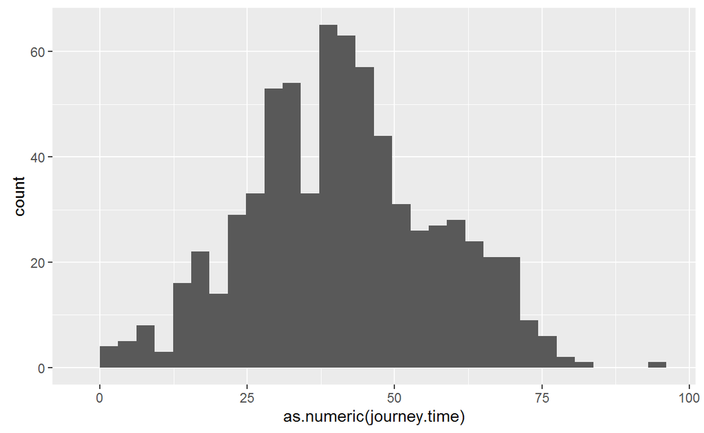

```r
qplot(x = as.numeric(journey.time), data = oyster)
```

## A simple histogram

That's ok, but the labels are horrible, so let's change them, and add a title. We can do that with the `xlab`, `ylab`, and `main` arguments:

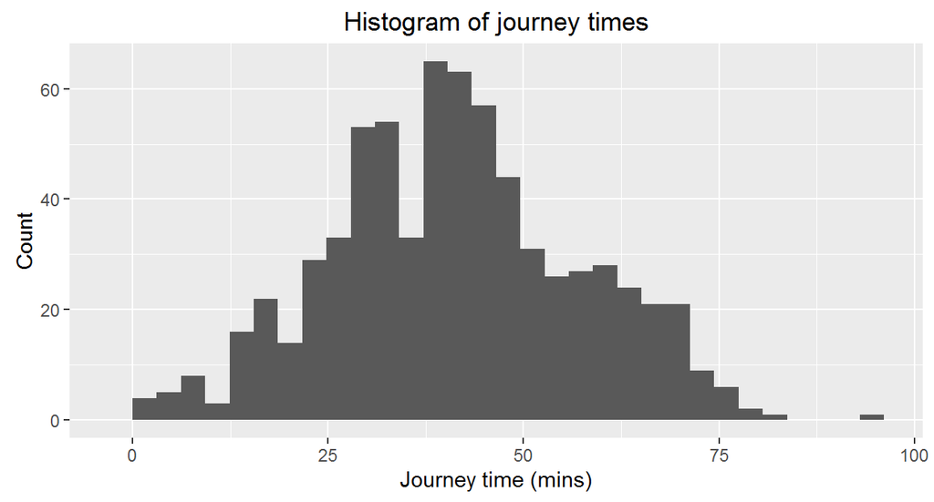

```r
qplot(x = as.numeric(journey.time), data = oyster, main = "Histogram of journey times",
      xlab = "Journey time (mins)", ylab = "Count")
```

## A simple histogram (code)

Lets add some colour to make it look a little prettier. We do this with the `fill` argument when we're *filling* in an area and `colour` to colour in lines or points.

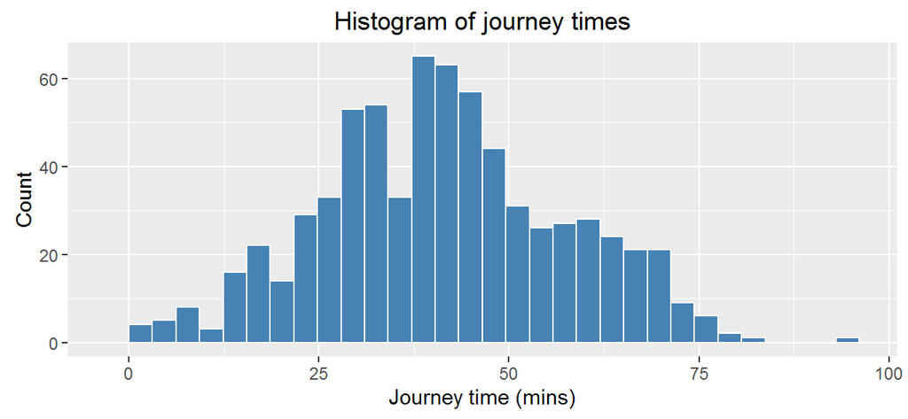

```r
qplot(x = as.numeric(journey.time), data = oyster, main = "Histogram of journey times",
      xlab = "Journey time (mins)", ylab = "Count", fill = I("steelblue"),
      colour = I("white"))
```

## A scatter plot

Another common visualisation is the scatter plot, for when we want to look at the relationship between two numeric variables. Lets look at the relationship between journey time and price.

Firstly, we'll need to cut out the 0-charge journeys.

```r
oyster_charged <- oyster %>%
                  filter(charge != 0)
```

## A scatter plot

It's then easy to create the scatter plot with `qplot`. Note that a scatter plot is the default for two numeric fields.

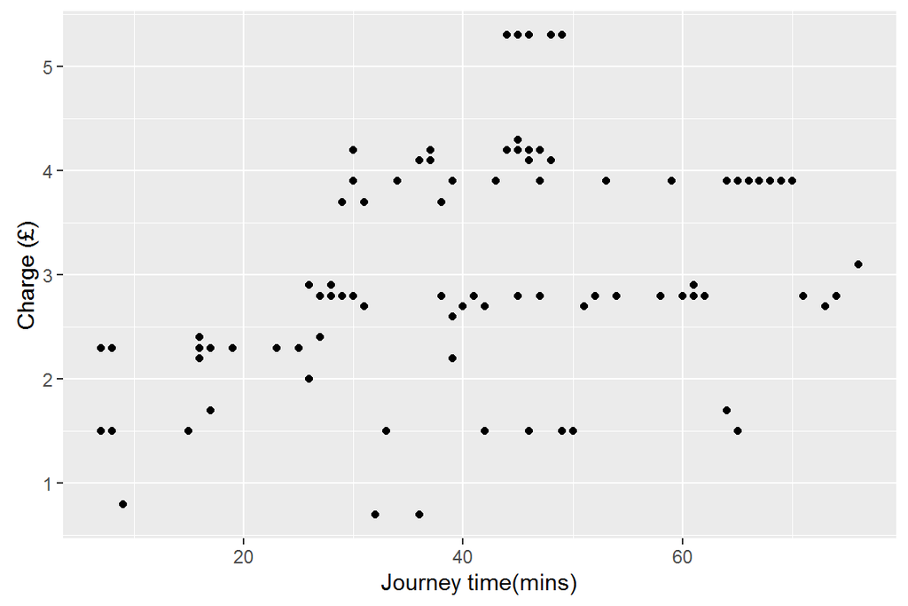

```r
qplot(x = as.numeric(journey.time), y = charge, data = oyster_charged,
      xlab = "Journey time(mins)", ylab = "Charge (£)")
```

## A scatter plot

To get sense of the relationship, we can also add a smoother using the `geom` argument:

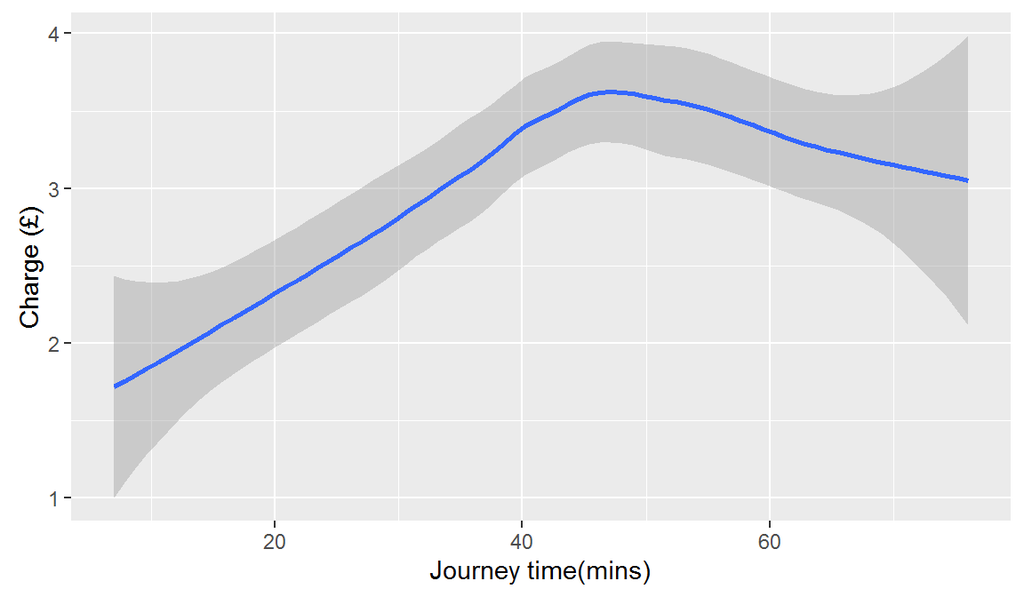

```r
qplot(x = as.numeric(journey.time), y = charge, data = oyster_charged,
      xlab = "Journey time(mins)", ylab = "Charge (£)", geom = "smooth")
```

## A scatter plot

Where have the points gone?! We only told `qplot` to display a smoother, we also need to tell it to display the points too:

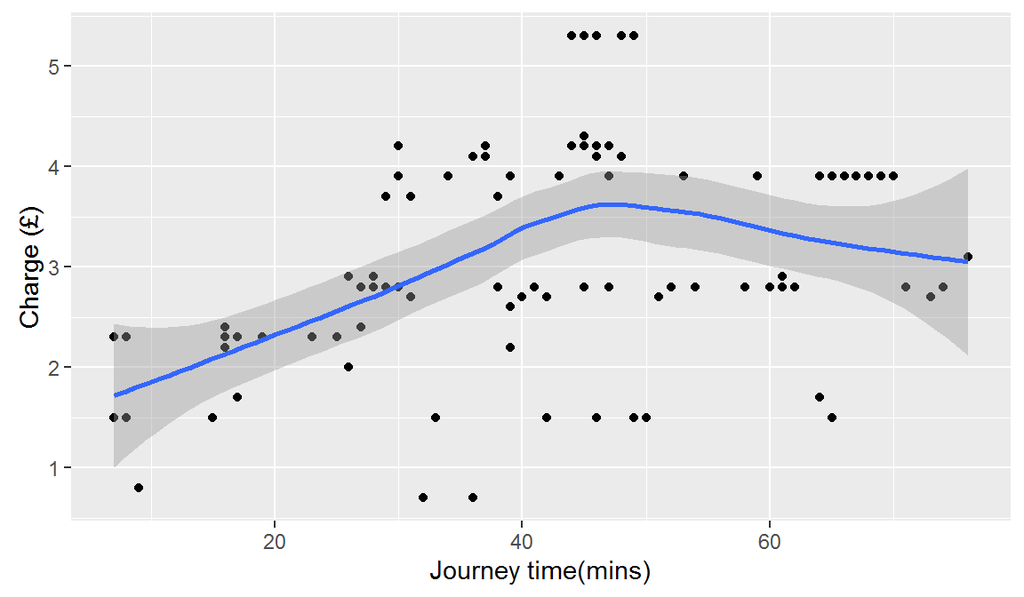

```r
qplot(x = as.numeric(journey.time), y = charge, data = oyster_charged,
      xlab = "Journey time(mins)", ylab = "Charge (£)", geom = c("point", "smooth"))
```

## A scatter plot (code)

We might also want to colour and/or shape the points depending on which day of the week the journey was on. Easily done with the `shape` and `colour` arguments (we'll remove the smoother for now).

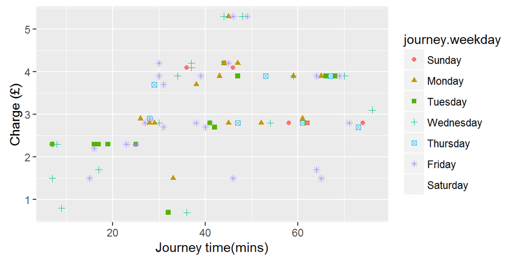

```r
qplot(x = as.numeric(journey.time), y = charge, data = oyster_charged,
      xlab = "Journey time(mins)", ylab = "Charge (£)", geom = c("point"),
      shape = journey.weekday, colour = journey.weekday)
```

## A note on colour and shape

We can use fields in our data to colour our plots in a really useful way.

However, if we want to just *set* the colour to be something specific, we need to wrap our choice of colour in the `I()` (identity) operator.

A full list of 657 built-in R colours can be found [here](http://www.stat.columbia.edu/~tzheng/files/Rcolor.pdf). You can also get palettes of colour from the `RColorBrewer` package, or create your own from *RGB* values.

## Box-plots

Boxplots can be great for understanding how a numerical value is distributed within a group. We can create one using the "boxplot" `geom`.

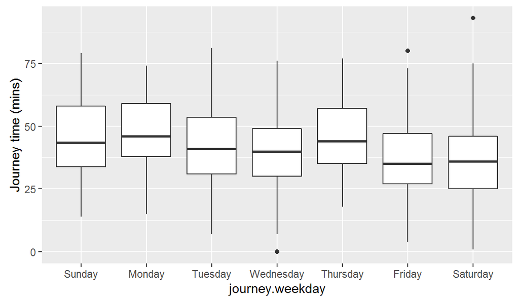

```r
qplot(x = journey.weekday, y = as.numeric(journey.time),
      data = oyster, geom = "boxplot", ylab = "Journey time (mins)")
```

## Creating another summary

To help us understand which stations we visit most, we'll create a new data set that summarises how often each station gets visited.

```r
visited <- oyster %>%
            select(from.clean, from.long, from.lat) %>%
            setNames(c("station", "longitude", "latitude")) %>%
            rbind(oyster %>%
                  select(to.clean, to.long, to.lat) %>%
                  setNames(c("station", "longitude", "latitude"))) %>%
            group_by(station, longitude, latitude) %>%
            summarise(visits = n()) %>%
            ungroup() %>%
            arrange(desc(visits))
```

## The limits of qplot

We're getting to the limits of what `qplot` can achieve for now. `qplot` was recently updated such that creating a bar chart is no longer an easy proposition, so we'll have to turn to `ggplot` for that.

Further tweaks will require us to use the `ggplot()` function itself. This is more complex and beyond the scope of this session, but if you're interested check out the excellent [documentation](http://docs.ggplot2.org/current/).

We'll look at a quick example, but go no further than that.

## Barcharts (code)

When we create a plot with `ggplot` we need to specify some data and an aesthetic layer. We then use `+` to add layers that build up the plot.

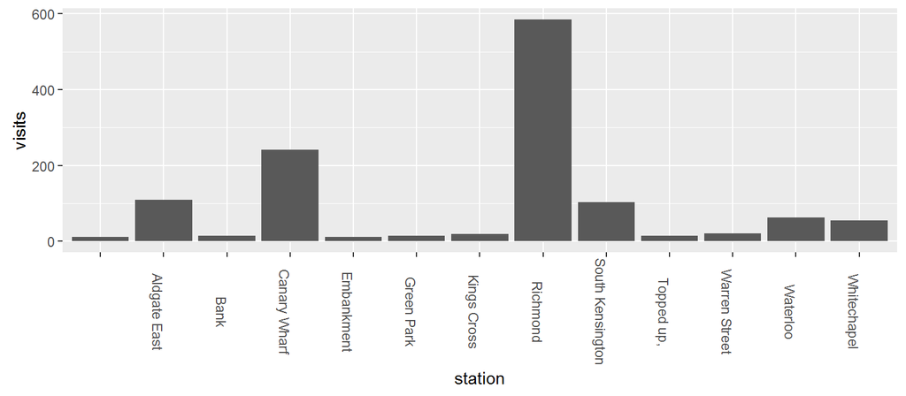

```r
top_visits <- filter(visited, visits >= 10)
ggplot(data = top_visits, aes(x = station, y = visits)) + geom_bar(stat = "identity") +
  theme(axis.text.x = element_text(angle = -90))
```

## An example

Let's have a look at an example plot we could make of journey times.

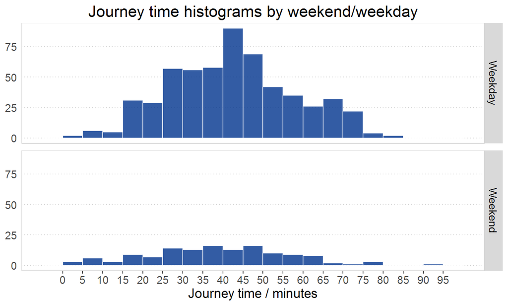

## leaflet

## An introduction to leaflet

`leaftlet` is actually a `JavaScript` library for creating interactive maps. The `R` package hides the `JS` underneath some easy-to-learn `R` functions and makes charting easy.

`leaflet` is great as it is lightweight, and supported by most browsers and desktop/mobile operating systems. This makes it great for creating shareable material from your analyses.

Here we're going to use it to plot station visits on a map.

## Using our summary

To help us out with our map, we'll use the data set that summarises how often each station gets visited, but this time without the filter.

```r
visited <- oyster %>%
            select(from.clean, from.long, from.lat) %>%
            setNames(c("station", "longitude", "latitude")) %>%
            rbind(oyster %>%
                  select(to.clean, to.long, to.lat) %>%
                  setNames(c("station", "longitude", "latitude"))) %>%
            group_by(station, longitude, latitude) %>%
            summarise(visits = n()) %>%
            filter(!is.na((longitude)))
```

## Creating the map (code)

```r
library(leaflet)
visited %>%
  leaflet() %>%
  addTiles() %>%
  addCircles(radius = 2.5*visits, stroke = T, fillOpacity = 0.75)
```

This code is all that is needed to make an interactive map. We first take our data summary and pass it to the `leaflet` function. Then, we add tiles (i.e. the map background) and then we add circles based on our data.

Maps like this can be a great way to explore interrogate geographical data. And if geography is important to your results, a map can really help demonstrate this.

## Reviewing the map

[interactive chart not shown]

## networkD3

## An introduction to networkD3

`NetworkD3` is another new `R` package that creates `d3.js`-based, interactive network diagrams. It might seem strange to visualise these data as a network, but in a way they are.

Journeys are made from nodes in the network to other nodes in the network (i.e. station to station) and we can start to imagine this in terms of a network dataset.

Whilst the data for just *one* traveler on the underground are not particularly interesting, if we had access to *everyone's* data, then we would have a really interesting network data set to investigate. Let's make a simple network plot.

## Creating the network diagram (code)

```r
library(networkD3)

oyster %>%
  group_by(from.clean, to.clean) %>%
  tally()  %>%
  simpleNetwork(zoom = TRUE)
```

Again, this simple snippet is all that's needed to create an interactive network diagram.

This package is still in its early life, so there are lots of features missing, but immediately we can look at the plot, explore it, and start to tell a story.

## Reviewing the network

[interactive chart not shown]

## Go fo-R it

## Shiny App

`Shiny` is a framework from RStudio that makes it really easy to make web apps based on your data. I made one with my Oyster data and you can find it online [here](https://jleach.shinyapps.io/oyster). Let's have a look and tell some stories.

You can also read about how I made it on my [blog](http://www.thedatagent.com/tflapprelease1/) and contribute to it via the [GitHub repository](https://github.com/Jim89/oyster) if that's something you're interested in.

## Closing R-marks

## Summary

In these last few sessions we've gone through a lot. We've covered:

- An introduction to R;
- Reading data in;
- Quick looks at your data;
- Simple data manipulations;
- Data cleaning;
- Working with dates;
- Working with strings;
- joining data together; and
- Some interesting visualisations we can make.

## Getting help - again

As we said at the beginning, there are lots of great sources of help for R problems. The top 3 are probably:

1. R help files: `?mean`, `?grep`
2. R package vignettes - can see those available with `vignette()`
3. [Google!](https://www.google.co.uk/#safe=off&q=r+help)

## Asking nicely

If you really have a problem that you can't solve yourself remember to:

1. Be explicit - state your problem in detail.
2. Describe the goal of your analysis - not the programming steps you're taking.
3. Provide reproducible examples - simulate the data if needs be.
4. Provide your hardware/software set up.

## More R-esources

There are loads of great sources of R information out there. Here are just a few:

- [CRAN](http://cran.r-project.org/doc/manuals/R-intro.pdf)
- [Coursera](https://www.coursera.org/specialization/jhudatascience/1?utm_medium=listingPage)
- [DataCamp](https://www.datacamp.com/)
- [Books](http://www.burns-stat.com/documents/tutorials/impatient-r/)
- [More books](http://www.burns-stat.com/documents/books/the-r-inferno/)
- [Even more books](http://adv-r.had.co.nz/)
- [R-Bloggers](http://www.r-bloggers.com/)

## Prize

To keep you going and learning with R, ICDSS are kindly sponsoring a small prize based on these workshops. What they're looking for is an exploratory and descriptive data analysis that tells a story about the Oyster data.

You can use any of the techniques we've covered in the sessions or anything else that you find online.

Responses can be in any format (we'd suggest investigating the `RMarkdown` reporting structure that RStudio have released) and focus on any aspect of the data that you'd like.

## Prize

Remember, the **main aim** of this exercise is to **learn and have fun** using R with some "real-life" messy data. So don't stress too much about it, discuss it with others (or with me!), and tell any story that you want to with the data.

**Submissions will be accepted up to 25th March.**

The prize is £50 to be used for attendance to the [Coursera](https://www.coursera.org/specializations/jhu-data-science) courses:

- Data Scientists Toolbox; and
- R-Programming